# Data Analysis on Women's Career, Income, and Parenthood

## Author: Xinyu Du, Kaiyuan Hou, Yulin Huang, Yi Yuan

# 1. Introduction and Motivation

This study investigates how the number of children a woman has influences her career outcomes, specifically focusing on wages, promotion opportunities, and labor force participation. The central question we aim to test is whether motherhood significantly affects women's professional advancement and earnings potential.

While structural barriers against working mothers are well-documented in China and many other countries—such as discrimination during pregnancy, reduced access to promotions, and wage penalties due to childcare responsibilities—the extent and mechanisms of these penalties in the U.S. labor market remain underexplored. The United States offers a different cultural, legal, and economic context, making it a valuable setting to examine whether similar patterns exist and, if so, to what degree.

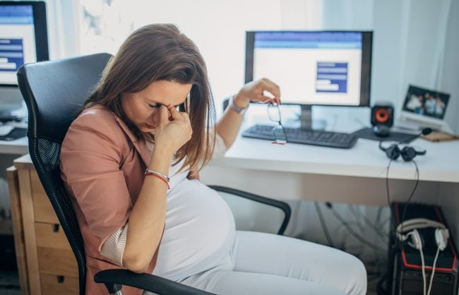

Understanding the motherhood penalty is crucial for policymakers, employers, and women navigating career planning. If the U.S. has developed successful strategies to mitigate motherhood-related career setbacks, identifying these factors could offer important lessons for shaping more equitable workplace policies globally, including in China. Conversely, if significant penalties persist, it highlights the urgent need for reforms even in advanced economies.

Supporting evidence from earlier research (Kahn et al., 2014; Even and Macpherson, 2001) demonstrates that motherhood penalties are particularly acute in early career stages but tend to diminish over time. However, these findings are based on outdated data and often neglect intersectional dimensions like race and class. More recent reports (University of Chicago and AP-NORC, 2023) reveal shifting societal attitudes toward parenthood and work, yet they fall short of quantifying the economic impacts. By leveraging up-to-date U.S. labor market data and applying an intersectional lens, this study aims to bridge these gaps and provide a more comprehensive understanding of how childbearing affects women’s economic trajectories.

# 2.Literature Review

### Factors Influencing Women’s Income: Six Recent Studies

### 1. U.S. Gender Wage Gap Trends and Explanations (Blau & Kahn, 2017)

#### Research Scope & Methods

Economists Francine Blau and Lawrence Kahn conducted a comprehensive literature review coupled with empirical analysis using U.S. data (Panel Study of Income Dynamics, 1980–2010). They aimed to identify how education, experience, occupation, industry, and other demographic factors explain the gender wage gap. Their study tracks the evolution of this gap over three decades and employs statistical decompositions to quantify the impact of each factor on women's earnings relative to men.

#### Key Findings

- **Narrowing Yet Persistent Gap:**
  - The gender wage gap narrowed significantly from 1980 to 2010 but stagnated among high earners. High-earning women still earned substantially less compared to their male counterparts, suggesting a greater disparity at the top of the income distribution.
- **Education and Experience:**
  - Traditional human capital factors (education and experience) now account for very little of the remaining wage gap, as women have largely matched men in these areas.
- **Occupational and Industrial Segregation:**
  - Women continue to predominantly occupy lower-paying industries and occupations. This occupational and industry segregation significantly contributes to the persistent wage gap, more so than education or other credentials.
- **Family Roles and Work Hours:**
  - Career interruptions and fewer work hours, often due to caregiving responsibilities, negatively impact women's earnings, especially in high-skilled, high-paying professions. This phenomenon, known as the "flexibility penalty," disproportionately affects women who prioritize flexible schedules.
- **Discrimination and Unexplained Gap:**
  - Even after accounting for measurable factors like education and occupation, a notable wage gap remains unexplained. Strong evidence from experimental research indicates ongoing discrimination in pay and promotion opportunities.
- **Emerging Factors:**
  - Psychological or non-cognitive skills (e.g., risk tolerance, negotiation skills) have a limited impact on the wage gap compared to occupational and industrial segregation. Such factors modestly influence earnings differences but are not major contributors.

#### Methodological Notes

The study combines quantitative analysis with an extensive literature review. Quantitative data from the U.S. Panel Study of Income Dynamics is analyzed to decompose the wage gap by observable factors. The subsequent literature review contextualizes these findings, incorporating evidence from experimental and international studies. This dual-method approach underscores the robustness of the findings, emphasizing occupational segregation, work-family dynamics, and potential discrimination as significant, ongoing contributors to the gender wage gap.

### 2. Global Analysis of Gender Pay Gaps (ILO Global Wage Report, 2018/19)

#### Research Scope & Methods

The International Labour Organization’s (ILO) 2018/19 Global Wage Report provides a quantitative global analysis of gender pay inequality, utilizing data from over 70 countries covering approximately 80% of wage employees worldwide. It employs various metrics such as average hourly, median, and monthly earnings gaps, and conducts decomposition analyses to identify how worker characteristics and unexplained factors contribute to gender wage disparities.

#### Key Findings

- **Global Gender Wage Gap:**
  - Globally, women earn approximately 16% less per hour on average than men. However, the gap varies significantly by country, ranging from -10% in the Philippines (women earning slightly more than men) to 34% in Pakistan.
- **Unexplained Wage Gap:**
  - In most countries, especially high-income ones, a substantial part of the wage gap remains unexplained after accounting for observable factors like education and job type. This points to discrimination, gender norms, or other unmeasured variables as significant causes.
- **Occupational Segregation:**
  - Women commonly occupy lower-paid jobs or sectors, which significantly contributes to wage disparities. Educational disparities, however, have minimal impact since younger women frequently match or exceed men's education levels globally.
- **Factor-weighted Gender Gap:**
  - A refined metric adjusting for industry and job type increases the global gender wage gap estimate from 16% to about 19%, indicating women earn less even within the same job categories.
- **Wage Distribution Patterns:**
  - In high-income countries, the wage gap widens significantly at higher earnings levels, illustrating a clear "glass ceiling." Conversely, low- and middle-income countries experience larger gaps at lower wage levels, highlighting disparities in informal or minimum-wage employment.
- **Motherhood Penalty:**
  - Women with children often face lower earnings due to career interruptions, part-time employment, and biases, exacerbating gender pay disparities. Insufficient childcare and unequal family responsibilities restrict women’s career growth.

#### Important Notes / Policy Implications

The report emphasizes policy interventions to address both measurable and deeper structural inequalities. Recommended policies include improving equal pay legislation, enhancing pay transparency, raising wages in women-dominated industries, and promoting equitable family responsibilities through improved childcare, parental leave, and flexible working arrangements.

### 3. Education, Race, and Gender Pay Disparities in the U.S. (Budig, Lim & Hodges, 2021)

#### Research Scope & Methods

Sociologists Michelle Budig, Misun Lim, and Melissa Hodges use an intersectional, quantitative approach to disentangle how race and education interact to affect women’s earnings in the United States. They analyze data from the National Longitudinal Survey of Youth 1979–2012, a representative panel following Americans over decades. The study investigates two primary factors explaining wage disparities: (1) educational attainment and field of study—whether minority women attain less education or pursue lower-paying majors—and (2) returns to education—whether women, particularly Black women, receive lower wage returns for equivalent educational credentials compared to other groups. They employ regression decomposition techniques to quantify the portion of wage gaps attributed to educational differences and random-effects models to examine differential wage returns to education.

#### Key Findings

- **Educational Attainment vs. Gender Gaps:**
  - Differences in education account for a significant share of racial pay gaps but do not explain the gender pay gap. Specifically, unequal education levels and college majors explain about 13–23% of the earnings gap between Black and white workers. However, these educational differences explain none of the gender pay gap between women and men. Women have attained sufficient educational parity with men, indicating other factors drive the persistent gender gap. Equalizing educational attainment could significantly reduce racial income disparities but would not eliminate the gender gap.
- **Lower Returns to Education:**
  - The study identifies clear evidence of unequal rewards for the same education. Men generally enjoy higher wage returns to each educational level compared to women, with this discrepancy being most pronounced for Black women. Black women experience particularly lower returns at the master’s degree level, indicating labor market inequalities extending beyond educational access, likely due to discrimination or occupational barriers.
- **Double Disadvantage for Black Women:**
  - Using an intersectional lens, the authors highlight that Black women face compounded disadvantages in earnings. Historically lower educational access (improving in recent generations) combined with lower returns on education means Black women are multiply disadvantaged. Even highly educated Black women earn significantly less than predicted if they were male or of another race with equivalent education. This dual disadvantage—educational attainment gaps and lower returns—substantially contributes to the large income disparity experienced by Black women.
- **Graphical Results & Statistical Illustrations:**
  - The study includes figures or charts from the decomposition analysis. A key visual finding is that equalizing educational attainment between Black and white women notably reduces the racial pay gap but leaves the gender gap largely intact across education levels, highlighting persistent occupational segregation and discrimination. Graphical representations clearly illustrate lower wage gains per additional degree for Black women compared to other groups, underscoring lower returns to education as a significant explanatory factor.

#### Methodological Notes

The study effectively distinguishes between group differences in attributes (education) and differences in how attributes are rewarded (returns to education), showing structural inequities in labor market valuation. Using a longitudinal panel dataset (1979–2012) enhances findings by capturing career-long wage trajectories, confirming the persistence of gender and racial gaps over time. The intersectional approach reveals that improving educational attainment alone is insufficient; policies must also target unequal pay structures. Recommended measures include stronger anti-discrimination enforcement and initiatives to guide minority women into higher-paying fields and roles.

### 4.Motherhood and the Persistent Gender Earnings Gap (Kleven et al. 2019)

#### Research Scope & Methods

Kleven and colleagues provide a clear statistical analysis of how family structure—particularly parenthood—affects women's earnings. Using administrative data from Denmark, this study tracks career paths of men and women before and after they become parents. They employ an event study design, aligning wage profiles at the birth of the first child and measuring the impact over time. Denmark, known for its generous parental leave and high female workforce participation, provides a critical context for isolating the effect of children on careers. The analysis covers cohorts from 1980 to 2013, examining both immediate and long-term earnings outcomes. The study also explores changes in women's job characteristics (occupation, sector, employer) after motherhood and intergenerational effects.

[figure not shown]

#### Key Findings

- **Large, long-term “child penalty” for women’s earnings**
  - Childbirth creates a significant and enduring divergence in earnings between genders. Women experience a sharp decline in earnings immediately following childbirth, which persists long-term, with women's earnings approximately 20% lower than their childless counterparts even a decade later. Fathers’ earnings remain largely unaffected, highlighting a clear gender disparity attributed to parenthood.
- **Mechanisms—hours, participation, and job choice:**
  - Three primary channels contribute to the motherhood penalty: reduced labor force participation, fewer working hours, and lower hourly wages. After childbirth, many women temporarily exit the workforce or shift to part-time roles, directly lowering earnings. Those who remain employed frequently transition into more flexible but lower-paying jobs, often in the public sector, leading to slower career progression and permanently lower income trajectories.
- **Dominance of child penalty in the gender gap:**
  - As other forms of gender inequality (such as educational attainment and single women's workforce participation) have improved, the penalty from motherhood has become the predominant factor driving gender wage inequality. In Denmark, approximately 80% of the current gender pay gap is attributed to the impact of children, reframing the gender wage gap as primarily a "childbearing pay gap."
- **Intergenerational transmission of norms:**
  - The study uncovers intergenerational effects, indicating daughters whose mothers experienced significant career setbacks due to childbearing are more likely to encounter similar penalties themselves. This suggests cultural or behavioral norms around family roles and career expectations are transmitted across generations, indicating that addressing these deep-seated norms requires sustained policy efforts.
- **Graphical Results:**
  - Visual representations show dramatic earnings trajectories for women post-childbirth, highlighting the sharp and persistent divergence from men's stable earnings paths. Graphs clearly demonstrate declines in women's employment rates, hours worked, and hourly wage rates immediately following childbirth, none of which rebound fully over subsequent years. These visualizations effectively illustrate the severe and lasting economic consequences of motherhood on women's careers.

#### Methodological Notes

The study's event-study approach, supported by robust administrative data, offers compelling causal evidence linking childbirth directly to women's earnings penalties. By comparing pre- and post-childbirth earnings trajectories and using men as a control group, the study isolates the childbirth effect convincingly. The Danish context provides additional credibility, as the persistence of significant penalties in a country with strong gender-equality policies suggests even greater challenges elsewhere. The findings underline the necessity of supportive policies such as affordable childcare, paternal leave, and flexible working conditions to mitigate the motherhood penalty effectively.

### 5.Intersection of Gender, Race, and Region in Wage Gaps (Chapman & Benis 2017)

#### Research Scope & Methods

Chapman and Benis examine the geographical dimensions of the gender wage gap in the U.S., analyzing how regional variations affect women’s earnings beyond individual characteristics.  
Using data from the National Women’s Law Center, they perform difference-in-means tests and linear regression models to evaluate the influence of regional location.  
The study controls for state-level economic and demographic factors to isolate the independent effects of geography.

#### Key Findings

- **Significant regional variation**:  
  Gender wage gaps vary widely across U.S. states. Northeastern states generally have smaller gaps, while Southern and Midwestern states show larger disparities. Latina women experience particularly pronounced disparities.
- **Independent regional effects**:  
  Even after controlling for economic conditions and demographics, regional location significantly impacts wage disparities, suggesting that local policies, norms, and discrimination patterns matter.
- **Intersectional insights**:  
  The magnitude of wage gaps for Latina and Black women varies greatly by region, highlighting the intersection of gender, race, and geography.
- **Graphical Results**:  
  Visualizations, including U.S. maps and comparative charts, illustrate regional disparities and intersectional patterns in gender wage gaps.

#### Methodological Notes

- The study demonstrates the necessity of incorporating geographical context into gender wage gap analyses.
- Aggregating state-level data with rigorous controls shows that regional-specific policies and cultural norms critically shape wage outcomes.
- Findings suggest the need for **targeted regional and local policy interventions** to address persistent disparities.

### 6.The Other Side of Organized Labor

#### Research Scope & Methods

The paper The Other Side of Organized Labor: Corruption and the Enforceability of Noncompete Agreements by Benmelech, Bergman, and Enrique (2023) examines an underexplored aspect of labor unions—their role in facilitating corruption by influencing the enforcement of noncompete agreements (NCAs). While existing literature has extensively studied unions' effects on wages and worker protections, this paper shifts focus to their potential negative externalities, particularly in contexts where unions collude with employers to restrict worker mobility.

#### Key Findings

- **Unions and Worker Protections**:  
  -Traditional labor economics emphasizes unions' role in improving wages and working conditions (Freeman & Medoff, 1984). However, recent studies suggest that unions may also engage in rent-seeking behavior (Hirsch, 2008). Benmelech et al. contribute to this debate by showing that unions can act as enforcers of NCAs, particularly in corrupt environments where legal institutions are weak. Their empirical analysis reveals that states with higher levels of union corruption exhibit significantly stricter enforcement of NCAs (Figure 2), supporting the hypothesis that unions may collude with firms to suppress competition.

[figure not shown]

- **Noncompete Agreements and Labor Market Rigidity:** -NCAs are typically justified as tools to protect trade secrets (Marx et al., 2009), but they can also stifle innovation and wage growth (Starr et al., 2021). Benmelech et al. extend this literature by demonstrating that unions, rather than always advocating for worker freedom, may help enforce NCAs when doing so benefits entrenched interests. Their regression results (Table 3) show a positive correlation between unionization rates and NCA enforceability in corrupt states, suggesting that union power does not uniformly benefit workers.

[figure not shown]

- **Corruption and Institutional Weakness:** -The paper also intersects with research on corruption and labor markets (Shleifer & Vishny, 1993). The authors find that in states with higher union corruption (measured by federal indictments of union officials), NCAs are more strictly enforced, reducing job mobility (Figure 4). This supports theories that institutional capture can distort labor markets (Acemoglu & Robinson, 2019), but uniquely implicates unions as active participants in such capture.

[figure not shown]

# 3. Data

### 3.1. Data Source

Data source: our data comes from IPUMS USA (https://usa.ipums.org/usa/index.shtml)

### 3.2. Data Description – 5 W’s

- **Who:**  
  The dataset comprises individual-level data on women in the United States.
- **What:**  
  It includes demographic and socioeconomic information such as age, income, occupation, education level, and marital status.
- **When:**  
  The data was collected over a five-year span, from 2018 to 2023.
- **Where:**  
  All data was gathered within the United States.
- **Why:**  
  The dataset provides essential variables for our research on factors that may impose influence on women's career.

### 3.3. Description of Interesting Data

Among all the variables in our dataset, we found factors such as marital status, race, and metropolitan status particularly interesting. While these variables may not seem directly related to income at first glance, they can play important moderating or contextual roles in shaping women's earnings. For instance, marital status may affect household responsibilities and dual-income dynamics; race can reflect underlying structural inequalities; and metropolitan status may capture differences in job markets, wage levels, and access to childcare. Investigating these factors may help reveal hidden patterns and deepen our understanding of the broader socioeconomic determinants of women's income.

### 3.4. General Description of the data

| Variables | Meaning | Code | Independent/Dependent |
| --- | --- | --- | --- |
| YEAR | Census year |  | Independent |
| NCHILD | Number of own children in the household |  | Independent |
| SEX | Sex | 1 for male, 2 for female | Independent |
| AGE | Age |  | Independent |
| MARST | Marital Status |  | Independent |
| EMPSTAT | Employment status | 1 for employed, 2 for unemployed | Independent |
| WKSWORK1 | Weeks worked last year |  | Dependent |
| INCTOT | Total personal income |  | Dependent |
| FTOTINC | Total family income |  | Dependent |
| INC_SHARE | Women's Individual-to-Household Income Ratio |  | Dependent |
| REGION | The region and division where the unit was located |  | Independent |
| METRO | Whether the household resided within a metropolitan area |  | Independent |
| RACED | Detailed info of Race |  | Independent |
| EDUC | educational attainment |  | Independent |
| EDUCD | Detailed info of EDUC |  | Independent |
| CLASSWKR | The class of worker |  | Dependent |
| WKSWORK1 | Weeks worked last year |  | Independent |
| INCTOT | Total personal income |  | Dependent |
| FTOTINC | Total family income |  | Dependent |
| INCWAGE | Wage and salary income |  | Dependent |

### 3.5 Data Cleaning

```python
import pandas as pd
import numpy as np
import matplotlib.pyplot as plt
import seaborn as sns
import dask.dataframe as dd
import statsmodels.formula.api as smf
from statsmodels.stats.outliers_influence import variance_inflation_factor
import statsmodels.api as sm

import warnings
warnings.filterwarnings('ignore')
```

```python
# Load the data
df = pd.read_csv('usa_00005.csv.gz')
```

```python
# Get a list of all columns in the DataFrame
existing_columns = df.columns.tolist()

# Columns to drop
columns_to_drop = ['WKSWORK1', 'RACED', 'EDUCD', 'EMPSTATD']

# Find common columns (columns that exist and need to be dropped)
common_columns = list(set(existing_columns) & set(columns_to_drop))

# Drop only the common columns if they exist
if common_columns:
  df = df.drop(columns=common_columns, axis=1)
```

```python
# Individual total income and family total income both are in 10k unit
df['INCTOT'] = df['INCTOT'] / 10000
df['FTOTINC'] = df['FTOTINC'] / 10000
df = df[~df['INCTOT'].isin([0, 9999999, 9999998])]
df = df[df['EMPSTAT'].isin([1, 2])] # 1: Employed, 2: Unemployed
df['INC_SHARE'] = df['INCTOT'] / df['FTOTINC'] *100 # Women's Individual-to-Household Income Ratio
print(df.shape)
print(df['NCHILD'].value_counts())
```

```
(4543963, 16)
0    2684641
1     812241
2     687162
3     256138
4      74692
5      19246
6       5903
7       2190
8        949
9        801
Name: NCHILD, dtype: int64
```

### 3.6 Charts and Plots

Before conducting our in-depth analysis, we performed a preliminary inspection of the dataset. During this initial exploration, we discovered several interesting patterns and observations worth noting.

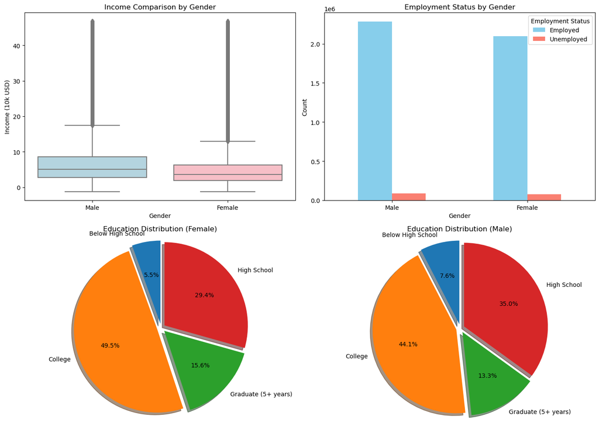

```python
filtered_df = df[(df['INCTOT'] < df['INCTOT'].quantile(0.99)) & (df['INCTOT'].notna())] # Excluded the extreme outliers
def group_education(code):
    if code in [0, 1, 2, 3, 4, 5]:
        return 'Below High School'
    elif code == 6:
        return 'High School'
    elif code in [7, 8, 9, 10]:
        return 'College'
    elif code == 11:
        return 'Graduate (5+ years)'
    else:
        return 'Other/Unknown'

df['EDUC_GROUP'] = df['EDUC'].apply(group_education)
female_df = df[df['SEX'] == 2]
male_df = df[df['SEX'] == 1]
female_educ_counts = female_df['EDUC_GROUP'].value_counts().sort_index()
male_educ_counts = male_df['EDUC_GROUP'].value_counts().sort_index()


emp_df = df[df['EMPSTAT'].isin([1, 2]) & df['SEX'].isin([1, 2])]
emp_counts = emp_df.groupby(['SEX', 'EMPSTAT']).size().unstack().fillna(0)
emp_counts.index = emp_counts.index.map({1: 'Male', 2: 'Female'})
emp_counts.columns = ['Employed', 'Unemployed']

fig, axes = plt.subplots(2, 2, figsize=(14, 10))

sns.boxplot(
    data=filtered_df,
    x='SEX',
    y='INCTOT',
    palette={1: 'lightblue', 2: 'lightpink'},
    ax=axes[0, 0]
)
axes[0, 0].set_xticks([0, 1])
axes[0, 0].set_xticklabels(['Male', 'Female'])
axes[0, 0].set_title('Income Comparison by Gender')
axes[0, 0].set_xlabel('Gender')
axes[0, 0].set_ylabel('Income (10k USD)')

emp_counts.plot(kind='bar', ax=axes[0, 1], color=['skyblue', 'salmon'], legend=True)
axes[0, 1].set_title('Employment Status by Gender')
axes[0, 1].set_xlabel('Gender')
axes[0, 1].set_ylabel('Count')
axes[0, 1].legend(title='Employment Status')
axes[0, 1].tick_params(axis='x', rotation=0)

axes[1, 0].pie(female_educ_counts, labels=female_educ_counts.index,
               autopct='%1.1f%%', startangle=90, explode=[0.05]*len(female_educ_counts),
               shadow=True)
axes[1, 0].set_title('Education Distribution (Female)')
axes[1, 0].axis('equal')

axes[1, 1].pie(male_educ_counts, labels=male_educ_counts.index,
               autopct='%1.1f%%', startangle=90, explode=[0.05]*len(male_educ_counts),
               shadow=True)
axes[1, 1].set_title('Education Distribution (Male)')
axes[1, 1].axis('equal')

plt.tight_layout()
plt.show()
```

# 4. Regression

### 4.1. Preliminary Regression analysis on Relevant Factors

Before conducting a deeper analysis on our topic of interest, we first aim to identify which variables in our dataset are potentially influential in determining women's income. To achieve this, we perform a series of preliminary simple regressions. This initial step serves two purposes:

1. To eliminate variables that show only weak correlation with women's income.
2. To highlight and retain the most relevant factors for further multivariate analysis.

This filtering process helps streamline our subsequent modeling and ensures we focus on the variables that meaningfully contribute to income variation among women.

### a. Race

Rather than applying a linear regression model to the `RACE` variable, we chose to treat it as a categorical variable with multiple levels. This is because `RACE` is encoded as discrete categories ranging from 1 to 9, each representing a different racial group, without any inherent numerical ordering.

Using regression directly on `RACE` as a numeric predictor would incorrectly assume a linear relationship between race codes and income, which is not meaningful. Instead, we opted for visualization techniques—such as boxplots and bar plots—to examine the distribution and average income across different racial groups. These methods allow us to capture income disparities across categories without imposing inappropriate numerical assumptions.

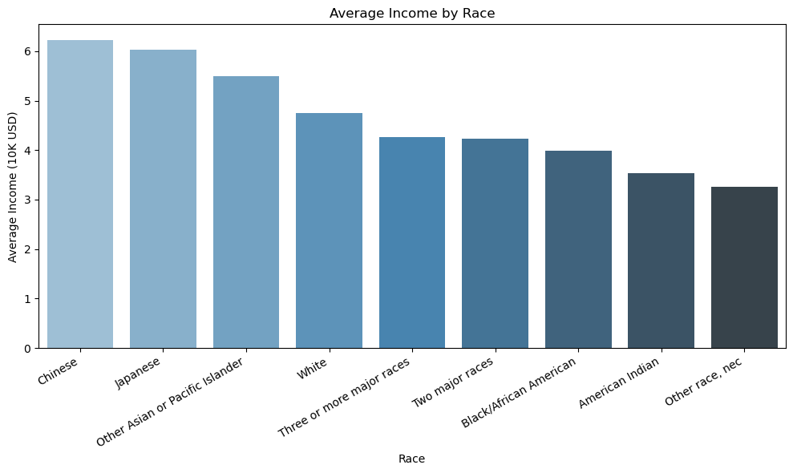

```python
df = df[df['SEX'] == 2] # For research purpose, we only keep females
# regression on race
race_mapping = {
    1: 'White',
    2: 'Black/African American',
    3: 'American Indian',
    4: 'Chinese',
    5: 'Japanese',
    6: 'Other Asian or Pacific Islander',
    7: 'Other race, nec',
    8: 'Two major races',
    9: 'Three or more major races'
}
df['RACE_LABEL'] = df['RACE'].map(race_mapping)
filtered_df = df[df['INCTOT'] < df['INCTOT'].quantile(0.99)].copy()
filtered_df['INCTOT'] = filtered_df['INCTOT']

race_income = filtered_df.groupby('RACE_LABEL')['INCTOT'].mean().reset_index()
race_income = race_income.sort_values(by='INCTOT', ascending=False)

plt.figure(figsize=(10, 6))
sns.barplot(data=race_income, x='RACE_LABEL', y='INCTOT', palette='Blues_d')
plt.title('Average Income by Race')
plt.xlabel('Race')
plt.ylabel('Average Income (10K USD)')
plt.xticks(rotation=30, ha='right')
plt.tight_layout()
plt.show()
```

The first figure presents a simple bar plot comparing the **average income** across racial groups.

We then apply a **categorical OLS regression**, treating `RACE` as a factor variable. This approach allows us to:

- Quantify how much each racial group’s income differs from a chosen **reference group** (in this case, White individuals),
- Assess whether those differences are **statistically significant**, and
- Construct **confidence intervals** for the estimated differences.

```python
from stargazer.stargazer import Stargazer
from IPython.core.display import HTML
pd.options.display.float_format = '{:.3f}'.format
model = smf.ols('INCTOT ~ C(RACE)', data=df).fit()

stargazer = Stargazer([model])
HTML(stargazer.render_html())

# Customizations
stargazer.title('Regression Results')
stargazer.covariate_order(['Intercept', 'C(RACE)[T.2]', 'C(RACE)[T.3]', 'C(RACE)[T.4]', 'C(RACE)[T.5]', 'C(RACE)[T.6]', 'C(RACE)[T.7]', 'C(RACE)[T.8]', 'C(RACE)[T.9]'])  # Specify the order of variables
stargazer.rename_covariates({'C(RACE)[T.2]': 'Black/African American', 'C(RACE)[T.3]': 'American Indian', 'C(RACE)[T.4]': 'Chinese', 'C(RACE)[T.5]': 'Japanese', 'C(RACE)[T.6]': 'Other Asian or Pacific Islander', 'C(RACE)[T.7]': 'Other race, nec', 'C(RACE)[T.8]': 'Two major races', 'C(RACE)[T.9]': 'Three or more major races'})  # Rename variables
stargazer.add_custom_notes(['Standard errors in parentheses'])

# Print the table as HTML
HTML(stargazer.render_html())
```

Regression Results

|  | *Dependent variable: INCTOT* |
| --- | --- |
|  | (1) |
| Intercept | 5.182*** |
|  | (0.005) |
| Black/African American | -1.003*** |
|  | (0.013) |
| American Indian | -1.513*** |
|  | (0.040) |
| Chinese | 2.029*** |
|  | (0.031) |
| Japanese | 1.555*** |
|  | (0.076) |
| Other Asian or Pacific Islander | 0.928*** |
|  | (0.019) |
| Other race, nec | -1.815*** |
|  | (0.020) |
| Two major races | -0.614*** |
|  | (0.019) |
| Three or more major races | -0.580*** |
|  | (0.061) |
| Observations | 2171288 |
| R<sup>2</sup> | 0.011 |
| Adjusted R<sup>2</sup> | 0.011 |
| Residual Std. Error | 5.848 (df=2171279) |
| F Statistic | 2932.987*** (df=8; 2171279) |
| Note: | *p<0.1; **p<0.05; ***p<0.01 |
| Standard errors in parentheses |  |

The estimated regression equation is:

$$ \begin{align*} \text{INCTOT} &=\ 5.182 \\ &\quad - 1.003 \cdot D_{\text{Black/African American}} \\ &\quad - 1.513 \cdot D_{\text{American Indian}} \\ &\quad + 2.029 \cdot D_{\text{Chinese}} \\ &\quad + 1.555 \cdot D_{\text{Japanese}} \\ &\quad + 0.928 \cdot D_{\text{Other Asian or Pacific Islander}} \\ &\quad - 1.815 \cdot D_{\text{Other race, nec}} \\ &\quad - 0.614 \cdot D_{\text{Two major races}} \\ &\quad - 0.580 \cdot D_{\text{Three or more major races}} \\ &\quad + \varepsilon \end{align*} $$

Where:

- The **baseline group** is *White*.
- Each race is a dummy variable equal to 1 if the individual identifies with that race category, and 0 otherwise.
- $ \varepsilon$ is the error term.

Summary: Race and Income Analysis

We observe that individuals identifying as **Chinese**, **Japanese**, or **Other Asian or Pacific Islander** have significantly higher incomes compared to the White baseline group. In contrast, groups such as **Black/African American**, **American Indian or Alaska Native**, and **Other race** exhibit notably lower average earnings.

However, the **R-squared value is only 0.011**, indicating that race alone explains just over **1% of the variation in income**. This suggests that while race is a relevant factor, other variables such as education, age, occupation, and region should be considered in further analysis. For this reason, we will continue to explore other variables.

### b. Age

Next, we will explore the effetc of age on womens' income level. By intuition, income will grow as age grows. Let's see if we can support our intuition by plot.

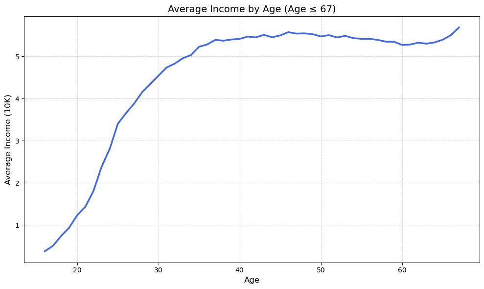

```python
filtered_df = df[(df['AGE'].notna()) & (df['INCTOT'].notna())]
filtered_df = filtered_df[
    (filtered_df['INCTOT'] < filtered_df['INCTOT'].quantile(0.99)) &
    (filtered_df['AGE'] <= 67)& # Full retirement age in US is 67.
    (filtered_df['EMPSTAT'] == 1)
]

age_income = filtered_df.groupby('AGE')['INCTOT'].mean().reset_index()

plt.figure(figsize=(10, 6))
sns.lineplot(data=age_income, x='AGE', y='INCTOT', linewidth=2.5, color='royalblue')
plt.title('Average Income by Age (Age ≤ 67)', fontsize=14)
plt.xlabel('Age', fontsize=12)
plt.ylabel('Average Income (10K)', fontsize=12)
plt.grid(True, linestyle='--', alpha=0.5)
plt.tight_layout()
plt.show()
female_30_40 = df[
    (df['SEX'] == 2) &
    (df['AGE'] >= 20) &
    (df['AGE'] <= 25) &
    (df['INCTOT'].notna())
]
```

Then let's build the model. The estimated linear regression model is specified as:

$$ \text{INCTOT}_i = \beta_0 + \beta_1 \cdot \text{AGE}_i + \varepsilon_i $$

Where:

- $\text{INCTOT}_i$ is the total personal income of individual $i$,
- $\text{AGE}_i$ is the age in years,
- $\beta_1$ captures the marginal effect of one additional year of age on income,
- $\varepsilon_i$ is the error term.

```python
model_age = smf.ols('INCTOT ~ AGE', data=df).fit()
ms = Stargazer([model_age])
HTML(ms.render_html())

# Customizations
ms.title('Regression Results')

# Print the table as HTML
HTML(ms.render_html())
```

Regression Results

|  | *Dependent variable: INCTOT* |
| --- | --- |
|  | (1) |
| AGE | 0.079*** |
|  | (0.000) |
| Intercept | 1.626*** |
|  | (0.012) |
| Observations | 2171288 |
| R<sup>2</sup> | 0.040 |
| Adjusted R<sup>2</sup> | 0.040 |
| Residual Std. Error | 5.760 (df=2171286) |
| F Statistic | 90528.855*** (df=1; 2171286) |
| Note: | *p<0.1; **p<0.05; ***p<0.01 |

- **Coefficient on AGE = 0.079:**  
  For every **one additional year of age**, **total income increases by 0.079 × 10,000 = \$790**, on average.
- **Intercept = 1.626:**  
  When age is 0 (which isn't realistic but is the mathematical intercept), the predicted income is **1.626 × 10,000 = \$16,260**.
- The **R² = 0.040** still indicates that **AGE alone explains only 4%** of the variation in income — so while the age-income relationship is significant, age is clearly not the whole story.

**Bottom Line** : Age has a positive and statistically significant effect on total income, but it explains only a small portion of the variation. For a more complete model, we'd want to include additional covariates

### c. Education

Intuitively, the regression model can be written as:

$$ \text{INCTOT} = \beta_0 + \beta_1 \cdot \text{EDUC} + \epsilon $$

```python
model_educ = smf.ols('INCTOT ~ EDUC', data=df).fit()
ms2 = Stargazer([model_educ])
HTML(ms2.render_html())

# Customizations
ms2.title('Regression Results')

# Print the table as HTML
HTML(ms2.render_html())
```

Regression Results

|  | *Dependent variable: INCTOT* |
| --- | --- |
|  | (1) |
| EDUC | 0.877*** |
|  | (0.002) |
| Intercept | -1.920*** |
|  | (0.014) |
| Observations | 2171288 |
| R<sup>2</sup> | 0.115 |
| Adjusted R<sup>2</sup> | 0.115 |
| Residual Std. Error | 5.530 (df=2171286) |
| F Statistic | 282450.860*** (df=1; 2171286) |
| Note: | *p<0.1; **p<0.05; ***p<0.01 |

$$ \widehat{\text{INCTOT}} = -1.920 + 0.877 \cdot \text{EDUC} $$

**Interpretation Summary:**

Importantly, the **R² = 0.115** indicates that education alone explains **11.5% of the variation** in income—almost **three times more explanatory power** than age did in the previous model. This reinforces the idea that education is a more influential predictor of income than age, although still not the whole story.

While a simple linear regression using the numeric `EDUC` codes provides a quick overview of the relationship between education and income, it assumes that the effect of education on income increases linearly with each education level.

However, in reality, the economic return to education may vary significantly across different stages of educational attainment. To capture these potential nonlinearities more accurately, we now treat `EDUC` as a categorical variable and run a regression using labeled education groups.

```python
educ_mapping = {
    0: 'No schooling',
    1: 'Nursery to grade 4',
    2: 'Grade 5-6',
    3: 'Grade 7-8',
    4: 'Grade 9',
    5: 'Grade 10',
    6: 'High school graduate',
    7: 'Some college, no degree',
    8: 'Associate degree',
    9: 'College 4 years',
    10: 'College 5+ years',
    11: 'Graduate degree'
}

# Map labels
df['EDUC_LABEL'] = df['EDUC'].map(educ_mapping)

# Run regression using labeled categorical variable
model = smf.ols('INCTOT ~ C(EDUC_LABEL)', data=df).fit()

# Create Stargazer output
stargazer = Stargazer([model])
stargazer.title('Income by Education Level')
HTML(stargazer.render_html())
```

Income by Education Level

|  | *Dependent variable: INCTOT* |
| --- | --- |
|  | (1) |
| C(EDUC_LABEL)[T.College 5+ years] | 1.918*** |
|  | (0.014) |
| C(EDUC_LABEL)[T.Grade 10] | -2.888*** |
|  | (0.030) |
| C(EDUC_LABEL)[T.Grade 5-6] | -1.992*** |
|  | (0.039) |
| C(EDUC_LABEL)[T.Grade 7-8] | -2.260*** |
|  | (0.048) |
| C(EDUC_LABEL)[T.Grade 9] | -2.671*** |
|  | (0.037) |
| C(EDUC_LABEL)[T.Graduate degree] | 4.736*** |
|  | (0.015) |
| C(EDUC_LABEL)[T.High school graduate] | -1.106*** |
|  | (0.013) |
| C(EDUC_LABEL)[T.No schooling] | -1.520*** |
|  | (0.042) |
| C(EDUC_LABEL)[T.Nursery to grade 4] | -1.848*** |
|  | (0.078) |
| C(EDUC_LABEL)[T.Some college, no degree] | -0.849*** |
|  | (0.015) |
| Intercept | 4.428*** |
|  | (0.011) |
| Observations | 2171288 |
| R<sup>2</sup> | 0.139 |
| Adjusted R<sup>2</sup> | 0.139 |
| Residual Std. Error | 5.457 (df=2171277) |
| F Statistic | 34916.389*** (df=10; 2171277) |
| Note: | *p<0.1; **p<0.05; ***p<0.01 |

**Summary: Income by Education Level**

Key findings:

- Individuals with a **graduate degree** earn significantly more than college graduates, with an average increase of **\$47,360**.
- Those with **less than a 4-year college education** generally earn significantly less than the reference group. For instance:
  - **Grade 10**: earns **\$28,880 less** on average
  - **High school graduates**: earn **\$11,060 less**
  - **Some college, no degree**: earn **\$8,490 less**
- The model explains **13.9%** of the variation in income $(R^2$ = 0.139), which is substantially higher than the `AGE`-only or `EDUC`-linear models.

This confirms a strong, non-linear relationship between education and income—especially a premium for advanced degrees and a penalty for not completing college.

### d. Marital status

Let's look at the barplot about the average income by marital status. Not married/single population has the lowest average income level and married with spour present population has the highest.

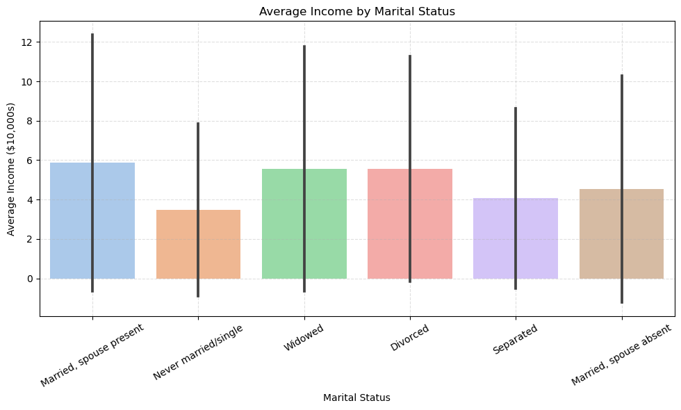

```python
# Define mapping for marital status
marst_mapping = {
    1: 'Married, spouse present',
    2: 'Married, spouse absent',
    3: 'Separated',
    4: 'Divorced',
    5: 'Widowed',
    6: 'Never married/single',
}

df_plot = df[df['MARST'] != 9].copy()

# Apply label mapping
df_plot['MARST_LABEL'] = df_plot['MARST'].map(marst_mapping)

# Plot average income by marital status
plt.figure(figsize=(10, 6))
sns.barplot(data=df_plot, x='MARST_LABEL', y='INCTOT', estimator=np.mean, ci='sd', palette='pastel')
plt.title('Average Income by Marital Status')
plt.ylabel('Average Income ($10,000s)')
plt.xlabel('Marital Status')
plt.xticks(rotation=30)
plt.grid(True, linestyle='--', alpha=0.4)
plt.tight_layout()
plt.show()
```

Since marital status is a complex and nuanced factor**—ranging from** never married**,** divorced**,** separated**, to** widowed**. Some women may be legally married but** living apart from their spouse**, while others may have** lost their partner**. To simplify this complexity for analysis, we use C(varname). This will convert the variable into a categorical instead of numerical and create dummy variables for each category.

```python
df = df[df['MARST'] != 9].copy() # Drop the missing values in MARST

model = smf.ols(formula="INCTOT ~ C(MARST)", data=df).fit()

stargazer = Stargazer([model])
stargazer.title("Regression of Income on Marital Status")
stargazer.custom_columns(['All'], [1])
stargazer.covariate_order(['Intercept'] + [v for v in model.params.index if 'C(MARST)' in v])
HTML(stargazer.render_html())
```

Regression of Income on Marital Status

|  | *Dependent variable: INCTOT* |
| --- | --- |
|  | All |
|  | (1) |
| Intercept | 5.865*** |
|  | (0.006) |
| C(MARST)[T.2] | -1.330*** |
|  | (0.029) |
| C(MARST)[T.3] | -1.795*** |
|  | (0.028) |
| C(MARST)[T.4] | -0.313*** |
|  | (0.012) |
| C(MARST)[T.5] | -0.311*** |
|  | (0.023) |
| C(MARST)[T.6] | -2.381*** |
|  | (0.009) |
| Observations | 2171288 |
| R<sup>2</sup> | 0.033 |
| Adjusted R<sup>2</sup> | 0.033 |
| Residual Std. Error | 5.782 (df=2171282) |
| F Statistic | 14699.591*** (df=5; 2171282) |
| Note: | *p<0.1; **p<0.05; ***p<0.01 |

This model estimates how **marital status (MARST)** affects total income (INCTOT), measured in **\$10,000s**, using categorical variables. Marital status is coded with integers from 1 to 6 (after excluding 9). The reference category is **`MARST=1`**, which represents **"Married, spouse present"**.

**Regression Equation:**

$$ \widehat{\text{INCTOT}} = 5.865 + \beta_j \cdot D_j $$

Where:

- $D_j$ is a dummy for each `MARST` category (2 to 6),
- All coefficients are interpreted relative to **MARST = 1** (the reference group),
- INCTOT is in **\$10,000 units**, so multiply by 10,000 for dollar interpretation.

**Coefficient Interpretation:**

| Marital Status | Coefficient | Interpretation (vs. Married, spouse present) |
| --- | --- | --- |
| **Married, spouse absent** (2) | -1.330 | Earns **\$13,300 less** on average |
| **Separated** (3) | -1.795 | Earns **\$17,950 less** |
| **Divorced** (4) | -0.313 | Earns **\$3,130 less** |
| **Widowed** (5) | -0.311 | Earns **\$3,110 less** |
| **Never married/single** (6) | -2.381 | Earns **\$23,810 less** |

- The **intercept = 5.865**, indicating that married individuals with a spouse present earn **\$58,650** on average.
- All effects are statistically significant at **p < 0.01**.
- **R² = 0.033**, indicating that marital status explains **3.3% of the variation** in income.
- The largest penalty is associated with being **never married/single**.
- **Divorced and widowed** individuals have smaller but still statistically significant income gaps.

**Conclusion:** Marital status has a significant effect on income. Individuals who are **not currently married and living with a spouse** earn considerably less, with **single (never married)** and **separated** individuals facing the largest income disadvantages. However, marital status alone does not explain most of the variance in income, suggesting other demographic and socioeconomic variables are also important.

### e. Maternal experience

Maternal experience is an important factor to consider when studying women's income. Unlike other variables such as age or education, it is unique to women and can have a direct impact on their career paths. Taking time off for childbirth and childcare often disrupts employment continuity, affects promotion opportunities, and may lead to long-term income penalties. Including this factor helps us better understand gender-specific challenges in the labor market.

As a starting point, we examine whether having children affects women's income. This forms an important part of maternal experience and serves as a key distinction in understanding how family roles may influence economic outcomes. By comparing women who have had children to those who have not, we aim to capture the initial income differences potentially associated with childbirth.

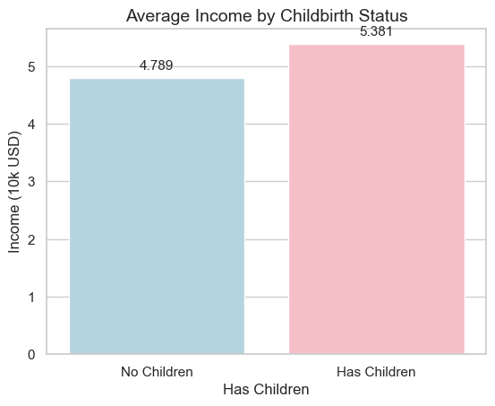

```python
# Filter and create binary child indicator
df_birth = df[df['NCHILD'].notna()].copy()
df_birth['HAS_CHILD'] = (df_birth['NCHILD'] > 0).astype(int)

# Barplot setup
sns.set(style="whitegrid")
plt.figure(figsize=(6, 5))
ax = sns.barplot(data=df_birth, x='HAS_CHILD', y='INCTOT', palette=['lightblue', 'lightpink'], ci=None)

# Custom x-axis labels
plt.xticks([0, 1], ['No Children', 'Has Children'])
plt.title('Average Income by Childbirth Status', fontsize=14)
plt.xlabel('Has Children')
plt.ylabel('Income (10k USD)')

# Add average value labels slightly above each bar
means = df_birth.groupby('HAS_CHILD')['INCTOT'].mean()
for i, mean in enumerate(means):
    ax.text(i, mean + 0.1, f'{mean:.3f}', ha='center', va='bottom', fontsize=11)

plt.tight_layout(pad=2)

plt.show()
```

The average income of women who have given birth appears **higher** than that of women who have not, as shown in the figure above. Having established that childbirth itself affects women’s income, we now turn our attention to women who have already had children. Specifically, we aim to investigate whether the **number of children** is associated with further variation in income levels. By focusing on this subgroup, we can better understand whether a greater parental burden translates into a stronger economic penalty, or if the income effect plateaus after childbirth occurs.

$$ \text{INCTOT} = \beta_0 + \beta_1 \cdot \text{NCHILD} + \epsilon $$

```python
model_nchild = smf.ols('INCTOT ~ HAS_CHILD', data=df_birth).fit()

stargazer = Stargazer([model_nchild])
HTML(stargazer.render_html())
```

|  | *Dependent variable: INCTOT* |
| --- | --- |
|  | (1) |
| HAS_CHILD | 0.592*** |
|  | (0.008) |
| Intercept | 4.789*** |
|  | (0.005) |
| Observations | 2171288 |
| R<sup>2</sup> | 0.002 |
| Adjusted R<sup>2</sup> | 0.002 |
| Residual Std. Error | 5.872 (df=2171286) |
| F Statistic | 5393.274*** (df=1; 2171286) |
| Note: | *p<0.1; **p<0.05; ***p<0.01 |

This regression shows that individuals with at least one child (`HAS_CHILD = 1`) earn, on average, **\$5,920 more** than those without children, controlling for no other factors. The relationship is statistically significant (**p < 0.01**), though the model explains only **0.2%** of the variation in income ($R^2 = 0.002$), indicating that while there's a detectable difference, having children alone is not a strong predictor of income.

We also explore the data by line plot:

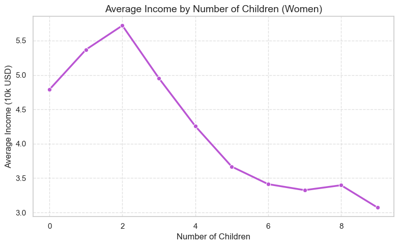

```python
avg_income_by_kids = df_birth.groupby('NCHILD')['INCTOT'].mean().reset_index()

plt.figure(figsize=(8, 5))
sns.lineplot(data=avg_income_by_kids, x='NCHILD', y='INCTOT', marker='o', linewidth=2.5, color='mediumorchid')
plt.title('Average Income by Number of Children (Women)', fontsize=14)
plt.xlabel('Number of Children')
plt.ylabel('Average Income (10k USD)')
plt.grid(True, linestyle='--', alpha=0.6)
plt.tight_layout()
plt.show()
```

The line chart clearly reveals a negative trend between the number of children and women’s average income. As the number of children increases, income levels show a marked decline. Interestingly, a slight rise in income is observed among women with one or two children, which we suspect may be attributed to older age or longer work experience. To further investigate this possibility and control for **age as a confounding factor**, we will stratify the data into **age groups** and examine the pattern within each segment.

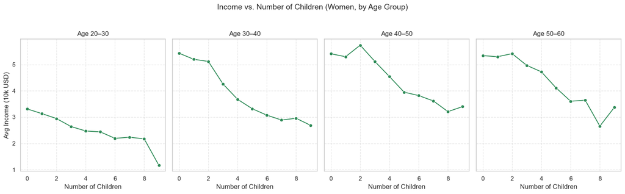

Income vs. Number of Children (Separate Regressions by Age Group)

|  | *Dependent variable: INCTOT* |  |  |  |
| --- | --- | --- | --- | --- |
|  | 20–30 | 30–40 | 40–50 | 50–60 |
|  | (1) | (2) | (3) | (4) |
| Intercept | 3.313*** | 5.543*** | 5.496*** | 5.351*** |
|  | (0.005) | (0.009) | (0.010) | (0.007) |
| NCHILD | -0.198*** | -0.360*** | -0.068*** | -0.050*** |
|  | (0.005) | (0.005) | (0.006) | (0.007) |
| Observations | 406841 | 425932 | 427326 | 468221 |
| R<sup>2</sup> | 0.004 | 0.013 | 0.000 | 0.000 |
| Adjusted R<sup>2</sup> | 0.004 | 0.013 | 0.000 | 0.000 |
| Residual Std. Error | 2.688 (df=406839) | 3.970 (df=425930) | 4.305 (df=427324) | 4.207 (df=468219) |
| F Statistic | 1603.534*** (df=1; 406839) | 5671.974*** (df=1; 425930) | 143.618*** (df=1; 427324) | 46.071*** (df=1; 468219) |
| Note: | *p<0.1; **p<0.05; ***p<0.01 |  |  |  |

```python
# Filter and prepare dataset
df_child = df[
    (df['SEX'] == 2) &
    (df['AGE'] >= 20) & (df['AGE'] <= 60) &
    (df['INCTOT'].notna()) &
    (df['NCHILD'].notna())
].copy()

df_child = df_child[df_child['INCTOT'] < df_child['INCTOT'].quantile(0.99)]

# Age group categorization
df_child['AGE_GROUP'] = pd.cut(
    df_child['AGE'],
    bins=[20, 30, 40, 50, 60],
    labels=['20–30', '30–40', '40–50', '50–60']
)

# Plot: Income vs. Number of Children by Age Group
age_groups = df_child['AGE_GROUP'].dropna().unique().sort_values()
fig, axes = plt.subplots(1, len(age_groups), figsize=(16, 5), sharey=True)

summary_rows = []

for i, group in enumerate(age_groups):
    sub_df = df_child[df_child['AGE_GROUP'] == group]
    model = smf.ols('INCTOT ~ NCHILD', data=sub_df).fit()

    summary_rows.append({
        'Age Group': str(group),
        'Coef (NCHILD)': round(model.params['NCHILD'], 4),
        'P-value': round(model.pvalues['NCHILD'], 4),
        'R-squared': round(model.rsquared, 4)
    })

    avg_income = sub_df.groupby('NCHILD')['INCTOT'].mean().reset_index()
    sns.lineplot(data=avg_income, x='NCHILD', y='INCTOT', marker='o', ax=axes[i], color='seagreen')
    axes[i].set_title(f'Age {group}')
    axes[i].set_xlabel('Number of Children')
    if i == 0:
        axes[i].set_ylabel('Avg Income (10k USD)')
    else:
        axes[i].set_ylabel('')
    axes[i].grid(True, linestyle='--', alpha=0.5)

plt.suptitle('Income vs. Number of Children (Women, by Age Group)', fontsize=14)
plt.tight_layout(rect=[0, 0, 1, 0.95])
plt.show()


# List to collect fitted models by age group
models_by_age = []

# Iterate over each age group and fit separate regression: INCTOT ~ NCHILD
for group in age_groups:
    sub_df = df_child[df_child['AGE_GROUP'] == group]
    if not sub_df.empty:
        model = smf.ols('INCTOT ~ NCHILD', data=sub_df).fit()
        models_by_age.append(model)

# Display all models in a single Stargazer table
stargazer = Stargazer(models_by_age)
stargazer.title('Income vs. Number of Children (Separate Regressions by Age Group)')
stargazer.custom_columns([str(g) for g in age_groups], [1] * len(age_groups))
HTML(stargazer.render_html())
```

The analysis reveals a consistent negative relationship between the number of children and women's income across all age groups. For women aged **20–30**, each additional child is associated with a **\$1,980** decrease in income, while the largest drop is observed among those aged **30–40**, at **\$3,600** per child. The effect weakens with age, shrinking to **\$680** for women aged **40–50** and **\$500** for those aged **50–60**. These trends are visually confirmed by the plots, which show steeper declines in average income among younger women as the number of children increases.

**Overall, the income penalty associated with childbirth clearly impacts the womens' income the most when they are/were young, and decreases with age, and eventually levels off.** This pattern suggests that the disruptive effect of maternal responsibilities on women's earnings is most pronounced earlier in life, but diminishes and stabilizes as age increases.

# 5. Collinearity Analysis

Before proceeding to multivariable regression, it is essential to examine potential collinearity among explanatory variables. Given that variables like age, education, marital status, and childbearing experience are all deeply intertwined in real life, high correlations between them could bias our regression estimates or inflate standard errors.

To ensure the reliability and interpretability of our final model, we perform a collinearity analysis using correlation matrices and Variance Inflation Factors (VIF). This step helps us detect and address any redundancy among predictors, thus improving the robustness and explanatory power of our regression results.

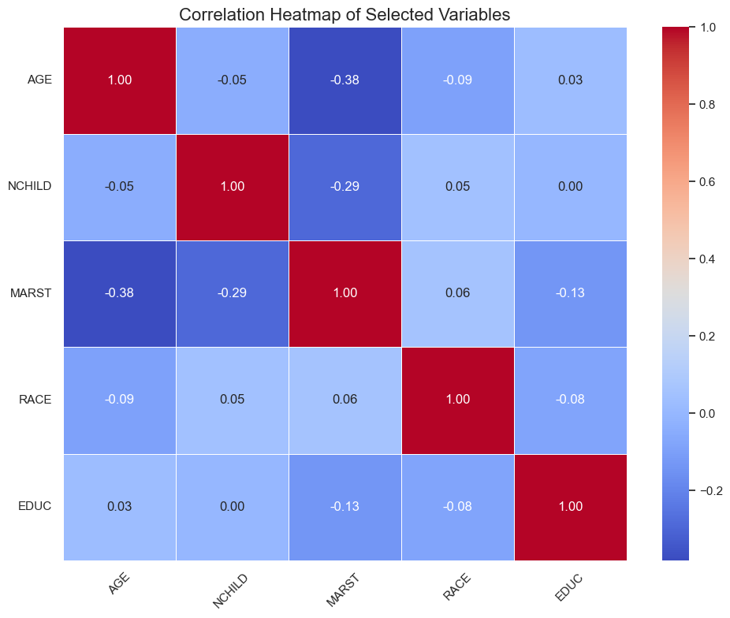

|  | Variable | VIF |
| --- | --- | --- |
| 0 | MARST | 1.348 |
| 1 | AGE | 1.215 |
| 2 | NCHILD | 1.136 |
| 3 | EDUC | 1.027 |
| 4 | RACE | 1.019 |

```python
selected_vars = ['AGE', 'NCHILD', 'MARST', 'RACE', 'EDUC']

df_clean = df[selected_vars].dropna()

df_encoded = df_clean.copy()
df_encoded['MARST'] = df_encoded['MARST'].astype('category').cat.codes
df_encoded['RACE'] = df_encoded['RACE'].astype('category').cat.codes
df_encoded['EDUC'] = df_encoded['EDUC'].astype('category').cat.codes

plt.figure(figsize=(10, 8))
sns.heatmap(df_encoded.corr(), annot=True, cmap='coolwarm', fmt='.2f', linewidths=0.5)
plt.title('Correlation Heatmap of Selected Variables', fontsize=16)
plt.xticks(rotation=45)
plt.yticks(rotation=0)
plt.tight_layout()
plt.show()

X = sm.add_constant(df_encoded)
vif_data = pd.DataFrame()
vif_data['Variable'] = X.columns
vif_data['VIF'] = [variance_inflation_factor(X.values, i) for i in range(X.shape[1])]
vif_data = vif_data[vif_data['Variable'] != 'const']
vif_data.sort_values(by='VIF', ascending=False).reset_index(drop=True)
```

**Conclusion:**

The correlation heatmap and VIF table together indicate that there is no serious multicollinearity among the selected explanatory variables (`AGE`, `NCHILD`, `MARST`, `RACE`, `EDUC`). All correlation coefficients are below ±0.4, and all VIF values are well below the commonly accepted threshold of 5. This confirms that these variables can be included in the same regression model without concerns about distorted coefficient estimates due to multicollinearity.

# 6. Methodology/Empirical Model

### 6.1 Model Choice

We use **Ordinary Least Squares (OLS)** to examine how various factors influence women's income. **Continuous variables** (e.g., age, education, number of children) are included directly. **Categorical variables** (e.g., race, marital status) are coded as **dummy variables**, with one category omitted as the **reference group** for interpretation.

Reference groups are selected based on frequency, economic relevance, and stability:

- **White women** for race,
- **Married women with husband present** for marital status.

### 6.2 Variables and Justification

- **Race (categorical):** Captures systemic inequality and labor market discrimination.
- **Age (continuous):** Proxy for experience; earnings typically rise with age.
- **Education (ordinal/continuous):** Reflects earning potential and job access.
- **Marital Status (categorical):** Impacts household income structure and support.
- **Number of Children (continuous):** Represents caregiving burden, which may reduce work hours or career progression.

### 6.3 Missing Variables and Limitations

Due to data constraints, we omit key variables like:

- **Occupation/Industry**
- **Region**
- **Weeks Worked last year**

These omissions may lead to:

- **Omitted Variable Bias**
- **Measurement Error**
- **Heteroskedasticity** (addressed using robust standard errors)

To improve predictions, we aim to consolidate smaller regressions into one comprehensive model.

### 6.4 Economic Hypotheses

- **Race:** Minority women earn less due to structural disadvantages and discrimination.
- **Age:** Income generally rises with experience, then flattens or falls.
- **Education:** Higher levels boost income through better job access.
- **Marital Status:** Married women may benefit from dual-income or caregiving support.
- **Children:** More children likely reduce income due to caregiving demands.

# 7. Multivariate Multiple Regression

### Motivation for Taking the Log of Income

In our multivariate regression model, we use the **natural logarithm of income (`ln(INCTOT)`)** as the dependent variable rather than raw income. This decision is based on several theoretical and empirical considerations:

1. **Income is Highly Skewed**  
   Personal income distributions are typically **right-skewed**, with a small number of individuals earning disproportionately high incomes. This skewness violates the **normality assumption** underlying OLS regression, which can distort coefficient estimates and significance tests. Log-transforming income makes the distribution more symmetric and closer to normal.
2. **Heteroskedasticity Concerns**  
   Without transformation, the variance of income tends to increase with the level of income, violating the OLS assumption of **constant error variance**. Applying the natural log stabilizes the variance across observations, helping to mitigate **heteroskedasticity** and improving the efficiency of our estimates.
3. **Interpretability of Coefficients**  
   In a log-linear model, coefficients can be interpreted approximately as **percentage changes** in income. This provides a more intuitive and meaningful way to understand the relationship between predictors (such as race, education, or marital status) and income levels.

### Final Model Structure

$$ \begin{align*} \ln(\text{INCTOT}_i) =\ & \beta_0 + \sum_{r=1}^{8} \beta_r \cdot D_{\text{Race}_r} + \beta_9 \cdot \text{AGE}_i + \beta_{10} \cdot \text{AGE}^2_i + \beta_{11} \cdot \text{EDUC}_i \\ &+ \sum_{m=1}^{5} \beta_{11+m} \cdot D_{\text{MaritalStatus}_m} + \beta_{17} \cdot \text{NCHILD}_i + \beta_{18} \cdot (\text{NCHILD}_i \times \text{AGE}_i) + \varepsilon_i \end{align*} $$

Where:

- $\ln(\text{INCTOT}_i)$ is the natural log of individual $i$’s total personal income,
- $D_{\text{Race}_r}$ are dummy variables for race (reference: White),
- $\text{AGE}_i$ and $\text{AGE}_i^2$ capture the **nonlinear age-income relationship**,
- $\text{EDUC}_i$ is education level,
- $D_{\text{MaritalStatus}}$ is marital status dummies (reference: Married with spouse present),
- $\text{NCHILD}_i$ is the number of children,
- $\text{NCHILD}_i \times \text{AGE}_i$ captures the **interaction between motherhood and age**,
- $\varepsilon_i$ is the error term.

This model allows us to more precisely estimate income drivers by addressing potential **nonlinearities**, **skewness**, and **interaction effects** present in the data.

```python
df['AGE_SQ'] = df['AGE'] ** 2
df['LN_INCTOT'] = np.log(df['INCTOT'])
model_final = smf.ols(
    'LN_INCTOT ~ C(RACE) + AGE + AGE_SQ + EDUC + C(MARST) + NCHILD + NCHILD:AGE',
    data=df
).fit(cov_type='HC3')

stargazer = Stargazer([model_final])
stargazer.title('Final Regression Results')
stargazer.rename_covariates({
    'C(RACE)[T.2]': 'Black',
    'C(RACE)[T.3]': 'American Indian/Alaska Native',
    'C(RACE)[T.4]': 'Chinese',
    'C(RACE)[T.5]': 'Japanese',
    'C(RACE)[T.6]': 'Other Asian/Pacific Islander',
    'C(RACE)[T.7]': 'Other Race',
    'C(RACE)[T.8]': 'Two Major Races',
    'C(RACE)[T.9]': 'Three+ Major Races',
    'AGE': 'Age',
    'AGE_SQ': 'Age Squared',
    'EDUC': 'Level of Education',
    'C(MARST)[T.2]': 'Married, Spouse Absent',
    'C(MARST)[T.3]': 'Separated',
    'C(MARST)[T.4]': 'Divorced',
    'C(MARST)[T.5]': 'Widowed',
    'C(MARST)[T.6]': 'Never Married/Single',
    'NCHILD': 'Number of Children',
    'NCHILD:AGE': 'Children × Age Interaction'
})


HTML(stargazer.render_html())
```

Final Regression Results

|  | *Dependent variable: LN_INCTOT* |
| --- | --- |
|  | (1) |
| Age | 0.117*** |
|  | (0.000) |
| Age Squared | -0.001*** |
|  | (0.000) |
| Married, Spouse Absent | -0.062*** |
|  | (0.005) |
| Separated | -0.112*** |
|  | (0.005) |
| Divorced | 0.033*** |
|  | (0.002) |
| Widowed | 0.166*** |
|  | (0.004) |
| Never Married/Single | -0.074*** |
|  | (0.002) |
| Black | -0.075*** |
|  | (0.002) |
| American Indian/Alaska Native | -0.082*** |
|  | (0.007) |
| Chinese | 0.113*** |
|  | (0.006) |
| Japanese | 0.022* |
|  | (0.013) |
| Other Asian/Pacific Islander | 0.054*** |
|  | (0.003) |
| Other Race | 0.020*** |
|  | (0.003) |
| Two Major Races | 0.014*** |
|  | (0.003) |
| Three+ Major Races | 0.008 |
|  | (0.011) |
| Level of Education | 0.170*** |
|  | (0.000) |
| Intercept | -3.034*** |
|  | (0.008) |
| Number of Children | 0.175*** |
|  | (0.003) |
| Children × Age Interaction | -0.005*** |
|  | (0.000) |
| Observations | 2169817 |
| R<sup>2</sup> | 0.297 |
| Adjusted R<sup>2</sup> | 0.297 |
| Residual Std. Error | 0.961 (df=2169798) |
| F Statistic | 39000.188*** (df=18; 2169798) |
| Note: | *p<0.1; **p<0.05; ***p<0.01 |

**Summary:**

The regression results show that most predictors significantly influence women's logged income at the 1% level. **Age** has a positive effect initially (coefficient = 0.117) but diminishes as women grow older, as indicated by the negative **AGE²** term (-0.001), confirming a concave (inverted U-shaped) relationship between age and income.

**Marital status** matters: compared to married women with a spouse present, women who are married but spouse absent, separated, or never married earn significantly less, while widowed women earn more. **Race** also shows large disparities: Black and American Indian women earn less than White women, while Asian and Pacific Islander women earn more. **Education** strongly boosts income (coefficient = 0.170), highlighting its key role in earnings potential.

Interestingly, **number of children (NCHILD)** alone raises income slightly (coefficient = 0.175), but the negative interaction with age (-0.005) suggests that as women with more children age, their income advantage diminishes.

Overall, the model explains about **30%** of the variation in income (**R² = 0.297**), and all major theoretical expectations—nonlinearity, race and marital disparities, education benefits, and motherhood penalties—are supported by the data.

# 8. Robustness Test

To ensure the robustness of our findings, we estimate several alternative specifications of the regression model. These allow us to test whether key relationships hold under different modeling choices.

### Test 1: Using Linear Income

```python
df['AGE_SQ'] = df['AGE'] ** 2
model_linear = smf.ols(
    'INCTOT ~ C(RACE) + AGE + AGE_SQ + EDUC + C(MARST) + NCHILD + NCHILD:AGE',
    data=df
).fit(cov_type='HC3')

stargazer = Stargazer([model_linear])

stargazer.title('Regression Results')
stargazer.covariate_order([
    'Intercept', 'C(RACE)[T.2]', 'C(RACE)[T.3]', 'C(RACE)[T.4]',
    'C(RACE)[T.5]', 'C(RACE)[T.6]', 'C(RACE)[T.7]', 'C(RACE)[T.8]',
    'C(RACE)[T.9]', 'AGE', 'AGE_SQ', 'EDUC', 'C(MARST)[T.2]',
    'C(MARST)[T.3]', 'C(MARST)[T.4]', 'C(MARST)[T.5]', 'NCHILD',
    'NCHILD:AGE'
])  # Specify the order of variables
stargazer.rename_covariates({
    'C(RACE)[T.2]': 'Black',
    'C(RACE)[T.3]': 'American Indian/Alaska Native',
    'C(RACE)[T.4]': 'Chinese',
    'C(RACE)[T.5]': 'Japanese',
    'C(RACE)[T.6]': 'Other Asian/Pacific Islander',
    'C(RACE)[T.7]': 'Other Race',
    'C(RACE)[T.8]': 'Two Major Races',
    'C(RACE)[T.9]': 'Three+ Major Races',
    'AGE': 'Age',
    'AGE_SQ': 'Age Squared',
    'EDUC': 'Levels of Education',
    'C(MARST)[T.2]': 'Married, Spouse Absent',
    'C(MARST)[T.3]': 'Separated',
    'C(MARST)[T.4]': 'Divorced',
    'C(MARST)[T.5]': 'Widowed',
    'C(MARST)[T.6]': 'Never Married/Single',
    'NCHILD': 'Number of Children',
    'NCHILD:AGE': 'Children × Age Interaction'
})

stargazer.add_custom_notes(['Robust standard errors in parentheses'])

# Display the table as HTML
HTML(stargazer.render_html())
```

Regression Results

|  | *Dependent variable: INCTOT* |
| --- | --- |
|  | (1) |
| Intercept | -7.894*** |
|  | (0.034) |
| Black | -0.448*** |
|  | (0.010) |
| American Indian/Alaska Native | -0.470*** |
|  | (0.026) |
| Chinese | 1.568*** |
|  | (0.042) |
| Japanese | 0.514*** |
|  | (0.092) |
| Other Asian/Pacific Islander | 0.650*** |
|  | (0.022) |
| Other Race | -0.123*** |
|  | (0.013) |
| Two Major Races | 0.101*** |
|  | (0.017) |
| Three+ Major Races | 0.150*** |
|  | (0.053) |
| Age | 0.255*** |
|  | (0.002) |
| Age Squared | -0.002*** |
|  | (0.000) |
| Levels of Education | 0.806*** |
|  | (0.002) |
| Married, Spouse Absent | -0.274*** |
|  | (0.028) |
| Separated | -0.581*** |
|  | (0.021) |
| Divorced | -0.072*** |
|  | (0.012) |
| Widowed | 0.174*** |
|  | (0.025) |
| Number of Children | 0.034*** |
|  | (0.013) |
| Children × Age Interaction | -0.001*** |
|  | (0.000) |
| Observations | 2171288 |
| R<sup>2</sup> | 0.162 |
| Adjusted R<sup>2</sup> | 0.162 |
| Residual Std. Error | 5.382 (df=2171269) |
| F Statistic | 21198.349*** (df=18; 2171269) |
| Note: | *p<0.1; **p<0.05; ***p<0.01 |
| Robust standard errors in parentheses |  |

### Test 2: Using Family Total Income

```python
df_birth['AGE_SQ'] = df_birth['AGE'] ** 2
df_birth = df_birth[df_birth['FTOTINC'] > 0].copy()
df_birth['LN_FTOTINC'] = np.log(df_birth['FTOTINC'])

model_spec1_fam = smf.ols(
    'LN_FTOTINC ~ C(RACE) + AGE + AGE_SQ + EDUC + C(MARST) + NCHILD + NCHILD:AGE',
    data=df_birth
).fit(cov_type='HC3')

stargazer = Stargazer([model_spec1_fam])

stargazer.title('Regression Results: Specification (Using Family Income)')
stargazer.covariate_order([
    'Intercept', 'C(RACE)[T.2]', 'C(RACE)[T.3]', 'C(RACE)[T.4]',
    'C(RACE)[T.5]', 'C(RACE)[T.6]', 'C(RACE)[T.7]', 'C(RACE)[T.8]',
    'C(RACE)[T.9]', 'AGE', 'AGE_SQ', 'EDUC', 'C(MARST)[T.2]',
    'C(MARST)[T.3]', 'C(MARST)[T.4]', 'C(MARST)[T.5]', 'NCHILD',
    'NCHILD:AGE'
])  # Specify the order of variables
stargazer.rename_covariates({
    'C(RACE)[T.2]': 'Black',
    'C(RACE)[T.3]': 'American Indian/Alaska Native',
    'C(RACE)[T.4]': 'Chinese',
    'C(RACE)[T.5]': 'Japanese',
    'C(RACE)[T.6]': 'Other Asian/Pacific Islander',
    'C(RACE)[T.7]': 'Other Race',
    'C(RACE)[T.8]': 'Two Major Races',
    'C(RACE)[T.9]': 'Three+ Major Races',
    'AGE': 'Age',
    'AGE_SQ': 'Age Squared',
    'EDUC': 'Levels of Education',
    'C(MARST)[T.2]': 'Married, Spouse Absent',
    'C(MARST)[T.3]': 'Separated',
    'C(MARST)[T.4]': 'Divorced',
    'C(MARST)[T.5]': 'Widowed',
    'C(MARST)[T.6]': 'Never Married/Single',
    'NCHILD': 'Number of Children',
    'NCHILD:AGE': 'Children × Age Interaction'
})
stargazer.add_custom_notes(['Robust standard errors in parentheses'])

HTML(stargazer.render_html())
```

Regression Results: Specification (Using Family Income)

|  | *Dependent variable: LN_FTOTINC* |
| --- | --- |
|  | (1) |
| Intercept | 3.149*** |
|  | (0.010) |
| Black | -0.174*** |
|  | (0.003) |
| American Indian/Alaska Native | -0.210*** |
|  | (0.007) |
| Chinese | 0.136*** |
|  | (0.007) |
| Japanese | 0.144*** |
|  | (0.013) |
| Other Asian/Pacific Islander | 0.130*** |
|  | (0.004) |
| Other Race | -0.132*** |
|  | (0.004) |
| Two Major Races | -0.000 |
|  | (0.004) |
| Three+ Major Races | 0.057*** |
|  | (0.013) |
| Age | -0.055*** |
|  | (0.000) |
| Age Squared | 0.000*** |
|  | (0.000) |
| Levels of Education | 0.085*** |
|  | (0.000) |
| Married, Spouse Absent | -0.487*** |
|  | (0.007) |
| Separated | -0.788*** |
|  | (0.005) |
| Divorced | -0.614*** |
|  | (0.002) |
| Widowed | -0.712*** |
|  | (0.004) |
| Number of Children | -0.685*** |
|  | (0.003) |
| Children × Age Interaction | 0.017*** |
|  | (0.000) |
| Observations | 2171007 |
| R<sup>2</sup> | 0.125 |
| Adjusted R<sup>2</sup> | 0.125 |
| Residual Std. Error | 1.059 (df=2170988) |
| F Statistic | 22374.851*** (df=18; 2170988) |
| Note: | *p<0.1; **p<0.05; ***p<0.01 |
| Robust standard errors in parentheses |  |

# 9. Conclusion

In sum, the U.S. labor market still exhibits a motherhood penalty, albeit within a broader context of demographic and social factors influencing women's earnings. Recognizing and addressing these disparities remains essential for promoting gender equity and supporting working mothers.

Looking forward, future work could be strengthened by incorporating additional variables such as occupation, industry, and work hours, allowing for better control of selection into different types of employment. Moreover, introducing interaction terms between race and education would provide a deeper understanding of how the motherhood penalty varies across different social groups, offering richer and more nuanced insights.

## Reference

1. Blau, F. D., & Kahn, L. M. (2017). The gender wage gap: Extent, trends, and explanations. Journal of Economic Literature, 55(3), 789–865. https://doi.org/10.1257/jel.20160995
2. Budig, M. J., & England, P. (2001). The wage penalty for motherhood. American Sociological Review, 66(2), 204–225. https://doi.org/10.2307/2657415
3. Budig, M. J., & Hodges, M. J. (2010). Differences in disadvantage: Variation in the motherhood penalty across white women’s earnings distribution. American Sociological Review, 75(5), 705–728. https://doi.org/10.1177/0003122410381593
4. Correll, S. J., Benard, S., & Paik, I. (2007). Getting a job: Is there a motherhood penalty? American Journal of Sociology, 112(5), 1297–1338. https://doi.org/10.1086/511799
5. Even, W. E., & Macpherson, D. A. (2001). Children and salaries: The impact of maternity on labor market outcomes. Economics Letters, 71(2), 269–273. https://doi.org/10.1016/S0165-1765(01)00356-5
6. Goldin, C. (2014). A grand gender convergence: Its last chapter. American Economic Review, 104(4), 1091–1119. https://doi.org/10.1257/aer.104.4.1091
7. Kleven, H., Landais, C., & Søgaard, J. E. (2019). Children and gender inequality: Evidence from Denmark. American Economic Journal: Applied Economics, 11(4), 181–209. https://doi.org/10.1257/app.20180010
8. Kahn, J. R., García-Manglano, J., & Bianchi, S. M. (2014). The motherhood penalty at midlife: Long-term effects of children on women's careers. Journal of Marriage and Family, 76(1), 56–72. https://doi.org/10.1111/jomf.12086
9. Petersen, T., Penner, A. M., & Høgsnes, G. (2014). From motherhood penalties to husband premia: The new challenge for gender equality. Sociological Perspectives, 57(4), 480–500. https://doi.org/10.1177/0731121414535254
10. University of Chicago & AP-NORC Center for Public Affairs Research. (2023). Parenthood, gender, and careers: Shifting perceptions and persistent challenges. Retrieved from https://apnorc.org/projects/parenthood-and-career-attitudes-2023/
11. Cukrowska-Torzewska, E., & Lovasz, A. (2020). The gender wage gap in the EU: What explains the differences across countries? International Labour Review, 159(1), 99–126. https://doi.org/10.1111/ilr.12144
12. Misra, J., Budig, M. J., & Boeckmann, I. (2011). Work-family policies and the effects of children on women's employment and earnings. Population Research and Policy Review, 30(6), 709–732. https://doi.org/10.1007/s11113-011-9213-7
13. Goldin, C., & Katz, L. F. (2011). The cost of workplace flexibility for high-powered professionals. The Annals of the American Academy of Political and Social Science, 638(1), 45–67. https://doi.org/10.1177/0002716211414822

```python
!jupyter nbconvert Econ_320_Final_project.ipynb --to html_embed
```

```
[NbConvertApp] Converting notebook Econ_320_Final_project.ipynb to html_embed
[NbConvertApp] Writing 2435342 bytes to Econ_320_Final_project.html
```